# Lecture 8: Exercises with Answers

October 26th, 2017

# Exercise I: Principal Component Analysis

Recall the `mtcars` dataset we work with before, which compirses fuel consumption and other aspects of design and performance for 32 cars from 1974. The dataset has 11 dimensions, that is more than it is possible to visualize at the same.

```r
head(mtcars)
```

|  | mpg | cyl | disp | hp | drat | wt | qsec | vs | am | gear | carb |
| --- | --- | --- | --- | --- | --- | --- | --- | --- | --- | --- | --- |
| Mazda RX4 | 21.0 | 6 | 160 | 110 | 3.90 | 2.620 | 16.46 | 0 | 1 | 4 | 4 |
| Mazda RX4 Wag | 21.0 | 6 | 160 | 110 | 3.90 | 2.875 | 17.02 | 0 | 1 | 4 | 4 |
| Datsun 710 | 22.8 | 4 | 108 | 93 | 3.85 | 2.320 | 18.61 | 1 | 1 | 4 | 1 |
| Hornet 4 Drive | 21.4 | 6 | 258 | 110 | 3.08 | 3.215 | 19.44 | 1 | 0 | 3 | 1 |
| Hornet Sportabout | 18.7 | 8 | 360 | 175 | 3.15 | 3.440 | 17.02 | 0 | 0 | 3 | 2 |
| Valiant | 18.1 | 6 | 225 | 105 | 2.76 | 3.460 | 20.22 | 1 | 0 | 3 | 1 |

1. Use `prcomp()` to compute a PCA for `mtcars`. Remember to set the scale parameter, as the variables are in different units and have different ranges

```r
mtcars.pca <- prcomp(mtcars, scale=TRUE)
```

2. Generate a scree plot and note how many dimensions should you retain.

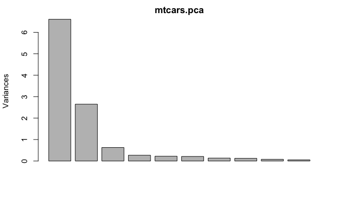

```r
plot(mtcars.pca)
```

3. Compute the percentage of variance explained by each of the principal components.

```r
eig <- mtcars.pca$sdev^2
(var.exp <- 100*eig/sum(eig))
```

```
 [1] 60.0763659 24.0951627  5.7017934  2.4508858  2.0313737  1.9236011  1.2296544  1.1172858  0.7004241  0.4730495
[11]  0.2004037
```

4. Generate a biplot for the PCA projection. Use the loadings matrix to inspect which variables contributes most to PC1 and which to PC2. What do the PC1 and PC2 correspond to? How are the cars distributed on this representation? Does the “car map” make sense?

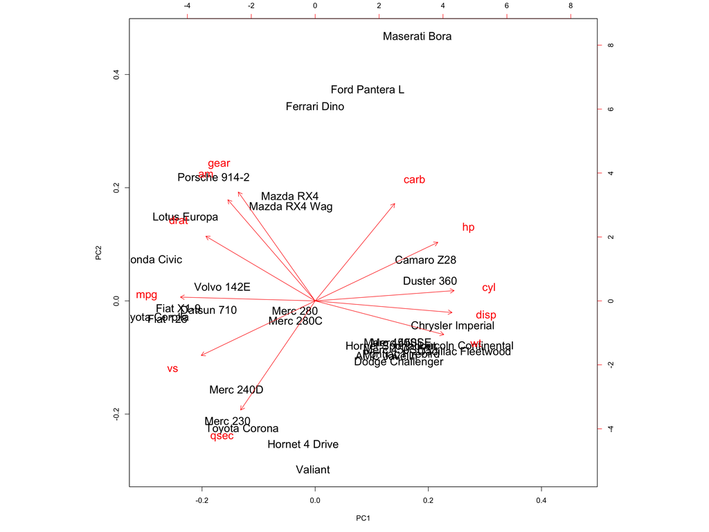

```r
biplot(mtcars.pca, cex = 1.5)
```

```r
mtcars.pca$rotation
```

```
            PC1         PC2         PC3          PC4         PC5         PC6          PC7          PC8          PC9
mpg  -0.3625305  0.01612440 -0.22574419 -0.022540255  0.10284468 -0.10879743  0.367723810 -0.754091423  0.235701617
cyl   0.3739160  0.04374371 -0.17531118 -0.002591838  0.05848381  0.16855369  0.057277736 -0.230824925  0.054035270
disp  0.3681852 -0.04932413 -0.06148414  0.256607885  0.39399530 -0.33616451  0.214303077  0.001142134  0.198427848
hp    0.3300569  0.24878402  0.14001476 -0.067676157  0.54004744  0.07143563 -0.001495989 -0.222358441 -0.575830072
drat -0.2941514  0.27469408  0.16118879  0.854828743  0.07732727  0.24449705  0.021119857  0.032193501 -0.046901228
wt    0.3461033 -0.14303825  0.34181851  0.245899314 -0.07502912 -0.46493964 -0.020668302 -0.008571929  0.359498251
qsec -0.2004563 -0.46337482  0.40316904  0.068076532 -0.16466591 -0.33048032  0.050010522 -0.231840021 -0.528377185
vs   -0.3065113 -0.23164699  0.42881517 -0.214848616  0.59953955  0.19401702 -0.265780836  0.025935128  0.358582624
am   -0.2349429  0.42941765 -0.20576657 -0.030462908  0.08978128 -0.57081745 -0.587305101 -0.059746952 -0.047403982
gear -0.2069162  0.46234863  0.28977993 -0.264690521  0.04832960 -0.24356284  0.605097617  0.336150240 -0.001735039
carb  0.2140177  0.41357106  0.52854459 -0.126789179 -0.36131875  0.18352168 -0.174603192 -0.395629107  0.170640677
            PC10         PC11
mpg   0.13928524 -0.124895628
cyl  -0.84641949 -0.140695441
disp  0.04937979  0.660606481
hp    0.24782351 -0.256492062
drat -0.10149369 -0.039530246
wt    0.09439426 -0.567448697
qsec -0.27067295  0.181361780
vs   -0.15903909  0.008414634
am   -0.17778541  0.029823537
gear -0.21382515 -0.053507085
carb  0.07225950  0.319594676
```

5. You can install the package `ggfortify` and use `autoplot` on `prcomp` objects to generate easily ggplots.

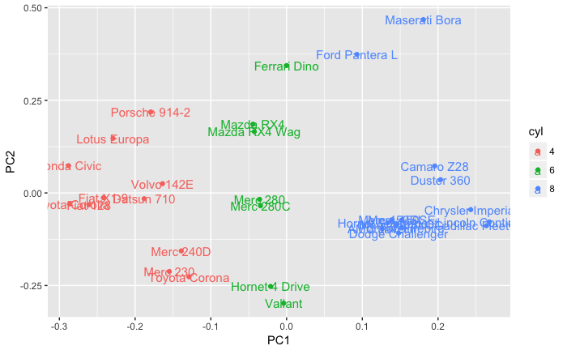

```r
# install.packages("ggfortify")
library(ggfortify)
library(dplyr)
mtcars <- mtcars %>%
  mutate(am = factor(am), gear = factor(gear), cyl = factor(cyl))
autoplot(mtcars.pca, data = mtcars, label = TRUE, label.size = 4, colour = 'cyl')
```

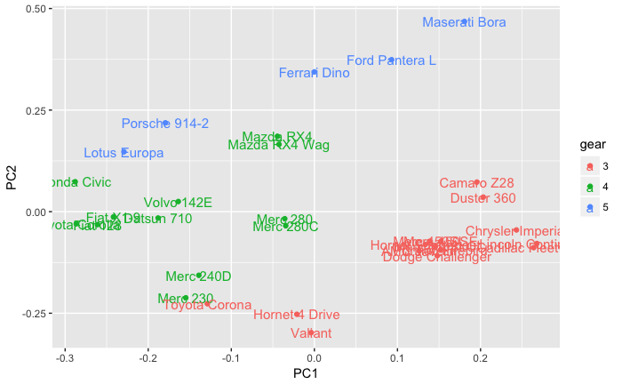

```r
autoplot(mtcars.pca, data = mtcars, label = TRUE, label.size = 4, colour = 'gear')
```

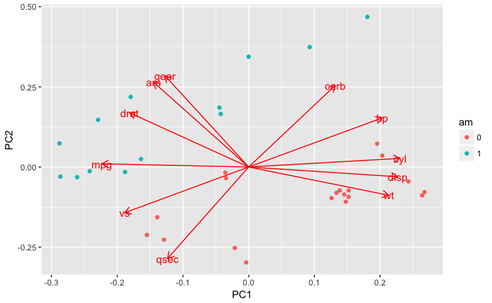

```r
autoplot(mtcars.pca, data = mtcars, label = FALSE, colour = 'am',
         loadings.label = TRUE, loadings.label.size  = 4)
```

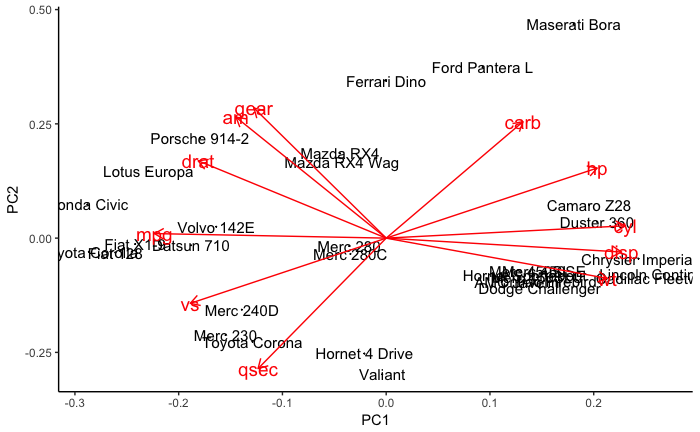

```r
autoplot(mtcars.pca, size = 0, label = TRUE, label.size = 4,
         loadings = TRUE, loadings.label = TRUE,
         loadings.label.size  = 5) + theme_classic()
```

# Exercise 2: Cluster Analysis

## Part 1: k-means clustering

We will generate synthetic clustered data to use for k-means clustering.

```r
set.seed(489576)
N <- 1000
C1 <- data.frame(cluster = "C1", x = rnorm(n = N, mean = 1), y = rnorm(n = N, mean = 1))
C2 <- data.frame(cluster = "C2", x = rnorm(n = N, mean = -2), y = rnorm(n = N, mean = -5))
C3 <- data.frame(cluster = "C3", x = rnorm(n = N, mean = 5), y = rnorm(n = N, mean = 1))
DF <- rbind(C1, C2, C3)
```

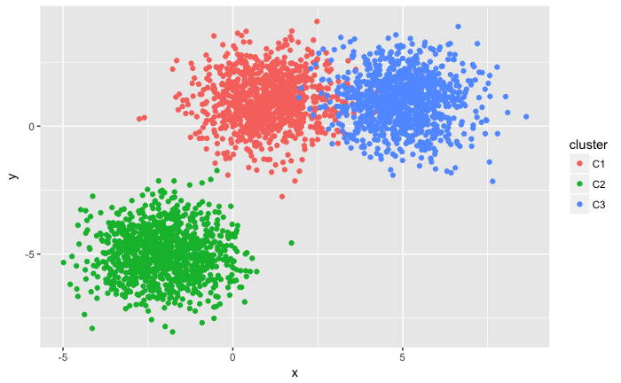

```r
ggplot(DF, aes(x, y, color = cluster)) +
  geom_point()
```

1. Apply k-means with k = 3 (as you know the true number of clusters). Pring the cluster centers.

```r
kmeans.res$centers
```

```
           x          y
1  0.9614141  1.0058486
2 -2.0431190 -4.9932291
3  5.0098346  0.9780214
```

2. Print a confusion map to compare k-means cluster assignment with the true cluster labels.

```r
table(kmeans = kmeans.res$cluster, true = DF$cluster)
```

```
      true
kmeans  C1  C2  C3
     1 968   1  23
     2   0 999   0
     3  32   0 977
```

3. Generate a scatter plot of points, now colored by the cluster assignment.

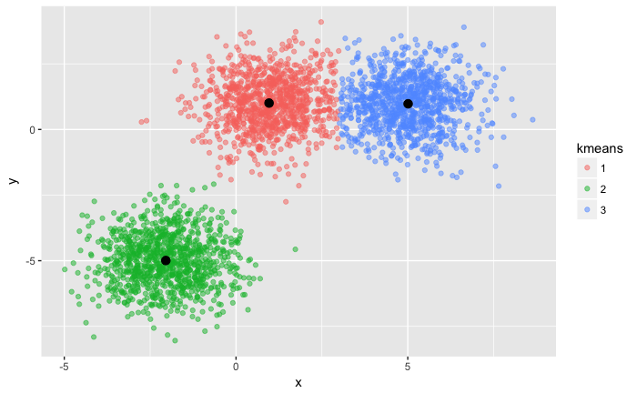

```r
library(ggplot2)
DF$kmeans <- factor(kmeans.res$cluster)
ggplot(DF, aes(x, y)) +
  geom_point(alpha = 0.5, aes( color = kmeans)) +
  geom_point(data = data.frame(x = kmeans.res$centers[, 1],
                               y = kmeans.res$centers[, 2]), size = 3, aes(x, y), color = "Black")
```

4. Now pretend that you don’t know the real number of clusters. Use k = 4 and recompute kmeans. Plot the results and see what happened.

```r
kmeans.res2 <- kmeans(x = DF[, -1], centers = 4)
kmeans.res2$centers
```

```
           x          y kmeans
1  5.3301476  1.7351006      3
2  4.7001362  0.2460306      3
3  0.9614141  1.0058486      1
4 -2.0431190 -4.9932291      2
```

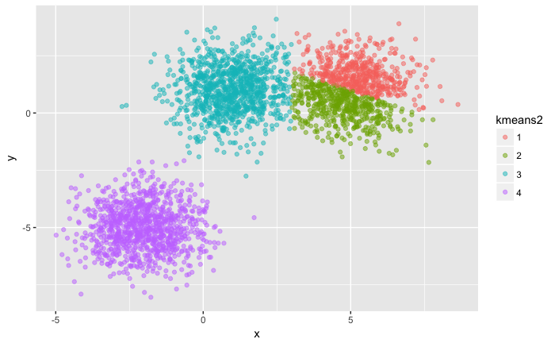

```r
DF$kmeans2 <- factor(kmeans.res2$cluster)
ggplot(DF, aes(x, y, color = kmeans2)) +
  geom_point(alpha = 0.5)
```

## Part 2: Hierarchical Clustering

In this exercise you will you use a dataset published in a study by [Khan et al. 2001](https://www.nature.com/articles/nm0601_673) to perform a hierarchical clustering of the patients in the study based on their overall gene expression data.

This data set consists of expression levels for 2,308 genes. The training and test sets consist of 63 and 20 observations (tissue samples) respectively.

Here, we will use the train set, as we now are only interested in learning how `hclust()` works. First, load the `ISLR` where the data is available. The gene expression data is available in an object `Khan$xtrain`; you can learn more about the data set by typing in `?Khan` after loading `ISLR` package.

```r
library(ISLR)
gene.expression <- Khan$xtrain
dim(gene.expression)
```

```
[1]   63 2308
```

1. Compute a (Euclidean) distance matrix between each pair of samples.

```r
D <- dist(gene.expression)
```

2. Perform hierarchical clustering using average linkage.

```r
khan.hclust <- hclust(D, method = "average")
```

3. Plot a dendrogram associated with the hierarchical clustering you just computed. In this example, you actually have the lables of the tissue samples, however, the algorithms was blinded to them. By adding labels to the dendrogram corresponding to `Khan$ytrain`, check if the clustering performed groups the observations from same tumor class nearby.

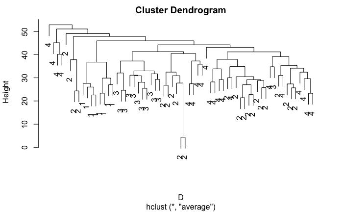

```r
plot(khan.hclust, labels = Khan$ytrain)
```

## Exercise Extra: 2D visualization of MNIST data

- Download MNIST data of the digits images from [Kaggle competition](https://www.kaggle.com/c/digit-recognizer).
- The code is adapted from the one found [here](https://www.kaggle.com/gospursgo/digit-recognizer/clusters-in-2d-with-tsne-vs-pca/code).

The files are data on the 28x28 pixel images of digits (0-9). The data is composed of:

- `label` column denoting the digit on the image
- `pixel0` through `pixel783` contain information on the pixel intensity (on the scale of 0-255), and together form the vectorized version of the 28x28 pixel digit image

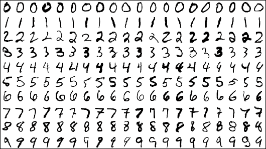

Download the data from the course repository:

|  | label | pixel0 | pixel1 | pixel2 | pixel3 | pixel4 | pixel5 | pixel6 | pixel7 | pixel8 |
| --- | --- | --- | --- | --- | --- | --- | --- | --- | --- | --- |
| 4776 | 5 | 0 | 0 | 0 | 0 | 0 | 0 | 0 | 0 | 0 |
| 26136 | 0 | 0 | 0 | 0 | 0 | 0 | 0 | 0 | 0 | 0 |
| 25589 | 7 | 0 | 0 | 0 | 0 | 0 | 0 | 0 | 0 | 0 |
| 26181 | 0 | 0 | 0 | 0 | 0 | 0 | 0 | 0 | 0 | 0 |
| 36156 | 9 | 0 | 0 | 0 | 0 | 0 | 0 | 0 | 0 | 0 |
| 26890 | 3 | 0 | 0 | 0 | 0 | 0 | 0 | 0 | 0 | 0 |
| 399 | 4 | 0 | 0 | 0 | 0 | 0 | 0 | 0 | 0 | 0 |
| 9766 | 1 | 0 | 0 | 0 | 0 | 0 | 0 | 0 | 0 | 0 |
| 27971 | 2 | 0 | 0 | 0 | 0 | 0 | 0 | 0 | 0 | 0 |
| 21594 | 6 | 0 | 0 | 0 | 0 | 0 | 0 | 0 | 0 | 0 |

1. Compute and the PCA for the data. Then, extract the first two principal component scores for the data.

```r
# compare with pca
pca <- prcomp(train[,-1])
coord.pca <- data.frame(pca$x[, 1:2])
coord.pca$label <- factor(train$label)
```

2. Plot the 2D principal component scores matrix.

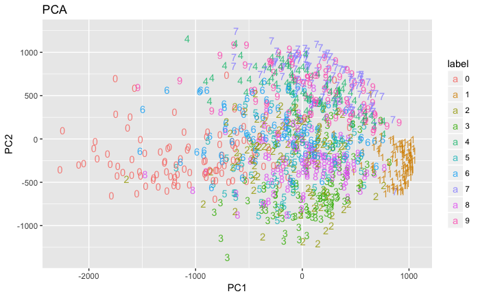

```r
ggplot(coord.pca, aes(x= PC1, y = PC2)) + ggtitle("PCA") +
  geom_text(aes(label = label, color = label), alpha = 0.8)
```

3. Compute a tSNE embedding.

```r
# Use tsne
library(Rtsne)
set.seed(123) # for reproducibility
tsne <- Rtsne(train[,-1], dims = 2, perplexity=30,
              verbose=FALSE, max_iter = 500)
coord.tsne <- data.frame(tsne$Y)
coord.tsne$label <- factor(train$label)
```

4. Visualize the tSNE 2D projection.

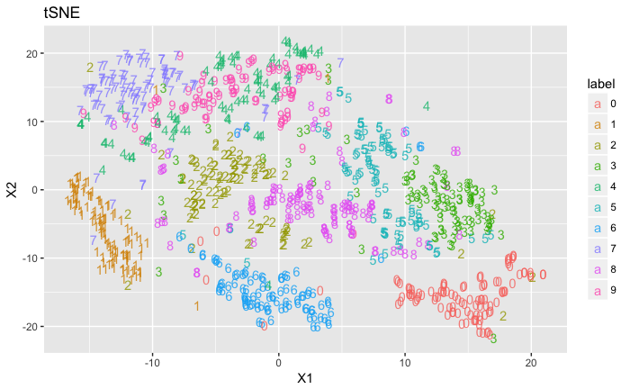

```r
# visualizing
ggplot(coord.tsne, aes(x= X1, y = X2)) + ggtitle("tSNE") +
  geom_text(aes(label = label, color = label), alpha = 0.8)
```

5. What do you observe? How does tSNE compare with PCA in this case?

tSNE seems to be much better at separating digits from each other